# Global Facebook Usage Analysis; An exploration of facebook user trends

# Libraries Used

```r
library(countrycode)
library(dplyr)
library(lubridate)
```

# Reading in the Data

Before beginning the analysis, read in the dataset that contains information about global Facebook usage, population, and different country names.

```r
Facebook<- read.csv("FB_bycountrydata.csv")
```

```r
head(Facebook)
```

|  | X | Name | Users | Facebook_Users. | Date_of_Data | Population | UsersFixed |
| --- | --- | --- | --- | --- | --- | --- | --- |
| 1 | 1 | United States | 240M | 70.59% | 2020-12 | 339,996,563 | 240000000 |
| 2 | 2 | Indonesia | 176.5M | 63.60% | 2021-06 | 277,534,122 | 176500000 |
| 3 | 3 | Brazil | 139M | 64.23% | 2020-12 | 216,422,446 | 139000000 |
| 4 | 4 | Philippines | 91M | 77.55% | 2021-06 | 117,337,368 | 91000000 |
| 5 | 5 | Mexico | 78M | 60.72% | 2020-12 | 128,455,567 | 78000000 |
| 6 | 6 | Vietnam | 75.9M | 76.82% | 2021-06 | 98,858,950 | 75900000 |

# Summary

In this project we look at Facebook usage across 126 countries to see how population size relates to the total number of Facebook users and the percentage of Facebook users in each country. First, the data was cleaned by making sure all columns are correctly formatted, removing extra characters, and making columns numeric. Countries were also grouped by continent in a new column so the regional comparison could be easier.

The results showed that the bigger the countries were, generally, the more Facebook users they’d have ,although, there are some exceptions like Russia that don’t follow this trend. For the User Percentage, we observed that it doesn’t really depend much on the Population size. This could be because of different factors like internet access, social media culture, or other personal user choices that also affect how many users a country has. Overall, these graphs helped understand and visualize global Facebook usage and it showed that population isn’t entirely the only factor that matters.

# Purpose

The main goal of this project is to analyze and vizualise global Facebook usage trends and patterns. Also, understand how population size relates to different factors like user percentage and total number of users globally and regionally.

Key questions

- Do countries with larger populations have more Facebook users?
- How does theuser percentage depend on population size?
- Which continent and countries have the greatest number of users?

# Information about Data Set

```r
summary(Facebook)
```

```
##        X              Name              Users           Facebook_Users.
##  Min.   :  1.00   Length:126         Length:126         Length:126
##  1st Qu.: 32.25   Class :character   Class :character   Class :character
##  Median : 63.50   Mode  :character   Mode  :character   Mode  :character
##  Mean   : 63.50
##  3rd Qu.: 94.75
##  Max.   :126.00
##  Date_of_Data        Population          UsersFixed
##  Length:126         Length:126         Min.   :     2600
##  Class :character   Class :character   1st Qu.:   135875
##  Mode  :character   Mode  :character   Median :  2550000
##                                        Mean   : 12514853
##                                        3rd Qu.:  7875000
##                                        Max.   :240000000
```

- **Name**: This column contains the names of 126 different countries - Categorial Data
- **UsersFixed**: Number of Facebook users in that country - Numerical Data
- **Facebook_Users**: Percentage of the population using Facebook - Numerical Data
- **Date_of_Data** : Date when data was collected - Categorical Data
- **Population**: Total population of that country - Numerical Data

### Cleaning each column(a quick summary)

From the summary, we can see that the User, UserPercentage, Date_of_Data, and Population columns are originally not numeric.

Cleaning these columns allows numerical vizualition and different operations to be done correctly. From the Name column we can see there are 126 entries, which means this is global data collected across 126 countries.

### Classifying all contries by their corresponding continent.

```r
Facebook$Continent <- countrycode(sourcevar = Facebook$Name,
                                       origin = "country.name",
                                       destination = "continent")
```

```r
Facebook %>%
  group_by(Continent) %>%
  summarize(Number_of_Countries = n())
```

| Continent | Number_of_Countries |
| --- | --- |
| Africa | 19 |
| Americas | 32 |
| Asia | 28 |
| Europe | 33 |
| Oceania | 14 |

### Cleaning the Population Column

Remove all non numeric characters and use as.numeric() to convert the column

```r
Facebook$Population <- gsub(" ", "",Facebook$Population )
```

```r
Facebook$Population <- gsub(",", "",Facebook$Population )
```

```r
Facebook$Population <- as.numeric(Facebook$Population)
```

### Cleaning the Facebook User Percentage Column

```r
Facebook$Facebook_Users.<- sub("%", "", Facebook$Facebook_Users.)
```

```r
Facebook$Facebook_Users. <- as.numeric(Facebook$Facebook_Users.)
```

```r
Facebook <- Facebook %>%
  rename(UserPercentage = Facebook_Users.)
```

### Cleaning the Date Column

```r
Facebook$Date_of_Data <- ym(Facebook$Date_of_Data)
```

```r
range(Facebook$Date_of_Data, na.rm = TRUE)
```

```
## [1] "2020-12-01" "2021-06-01"
```

The Date_of_Data column was converted to date format using Year-Month format so a place holder day (-01) is added. This allows to visualize the period during which the data was collected. This gives us context to the dataset and the earliest and latest dates data was collected. This helps us understand the timeframe, which is from December 2020 to June 2021.

### Scalling Population and UsersFixed columns for plotting purposes

```r
Facebook$Population_mill <- Facebook$Population / 1000000
Facebook$Users_mill <- Facebook$UsersFixed /1000000
```

# Exploratory Data Analysis

## a. Scatterplots

The following section shows scatterplots used to identify trends between population, Facebook users, and user percentage.

In this graph we compare the number of Facebook users(not percentage) compared to the population of these countries. We can observe a clear positive trend, where the larger the population of these countries is , the more Facebook users they tend to have.However,there are a some outliers, countries with populations around 25 and 50 million.In particular, Rusia shows a very low user to population ratio. These outliers do not follow the gener trens observed in the rest of the data

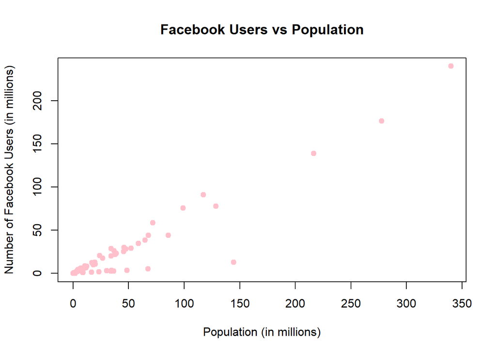

```r
options(scipen=999)

plot(Facebook$Population_mill,
     Facebook$Users_mill,
     xlab = "Population (in millions)",
     ylab = "Number of Facebook Users (in millions)",
     main = "Facebook Users vs Population",
     col = "pink",
     pch = 19)
```

In this graph, we compare the percentage of the population using Facebook across countries of different population sizes. This graph shows no clear positive or negative trend unlike the previous plot. The countries with larger population don’t necessarily show higher user percentages. Most countries fall around the 50-80% of users forming some what of a cluster around that area. There are also some outlier with unusually high or low percentages compared to the cluster. This graph helps showing that country size alone wont determine the percentage of users on Facebook. This might be due to different like internet penetration, other social media platforms, and just general cultural preferences.

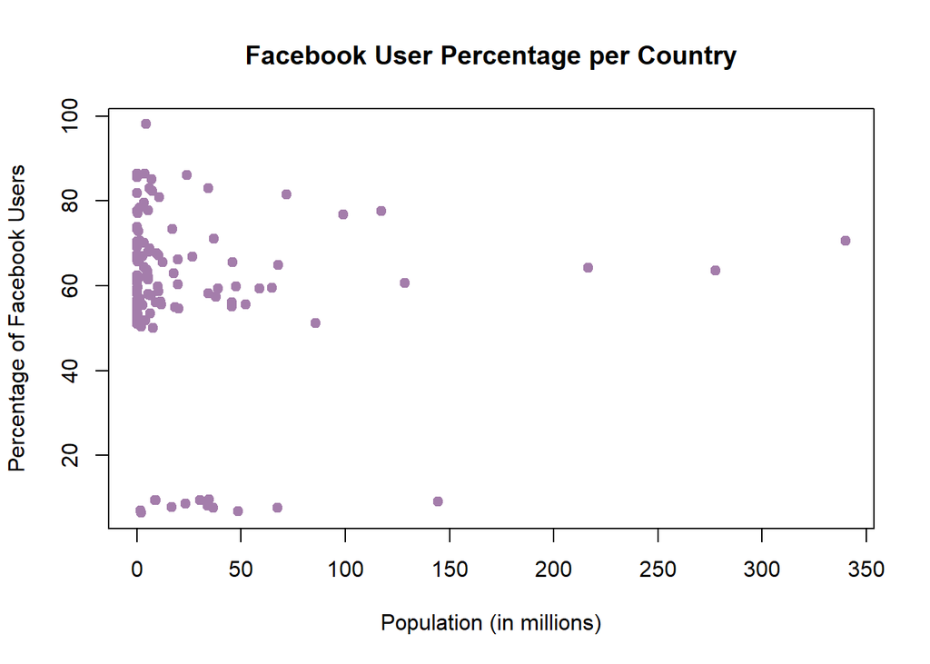

```r
plot(Facebook$Population_mill,
     Facebook$UserPercentage,
     xlab = "Population (in millions)",
     ylab = "Percentage of Facebook Users",
     main = "Facebook User Percentage per Country",
     col = "#a47dab",
     pch = 19)
```

## b. Data By Continent

These two tables show the total Facebook users and population for each continent, giving us a clear idea of the scale of our data and how users are distributed. Making it a quick summary before we get to the barplots.

```r
Facebook %>%
  group_by(Continent) %>%
  summarise(Users_Per_Continent = sum(UsersFixed))%>%
  arrange(desc(Users_Per_Continent))
```

| Continent | Users_Per_Continent |
| --- | --- |
| Asia | 626549800 |
| Americas | 594343200 |
| Europe | 246439000 |
| Africa | 86753100 |
| Oceania | 22786400 |

```r
Facebook %>%
  group_by(Continent) %>%
  summarise(Population_Per_Continent = sum(Population)) %>%
  arrange(desc(Population_Per_Continent))
```

| Continent | Population_Per_Continent |
| --- | --- |
| Asia | 937590064 |
| Americas | 914063021 |
| Europe | 527136538 |
| Africa | 407031872 |
| Oceania | 33888517 |

## c. Graphs By Continent

These barplots are made to compare the number of Facebook users across countries within each continent. Making it visually easy to see which countryes have the largest user bases and how it varies.

The following barplots show the number of Facebook users in each country within a specific continent. The x-axis lists the countries, while the y-axis shows the total number of users in millions.

### Asia

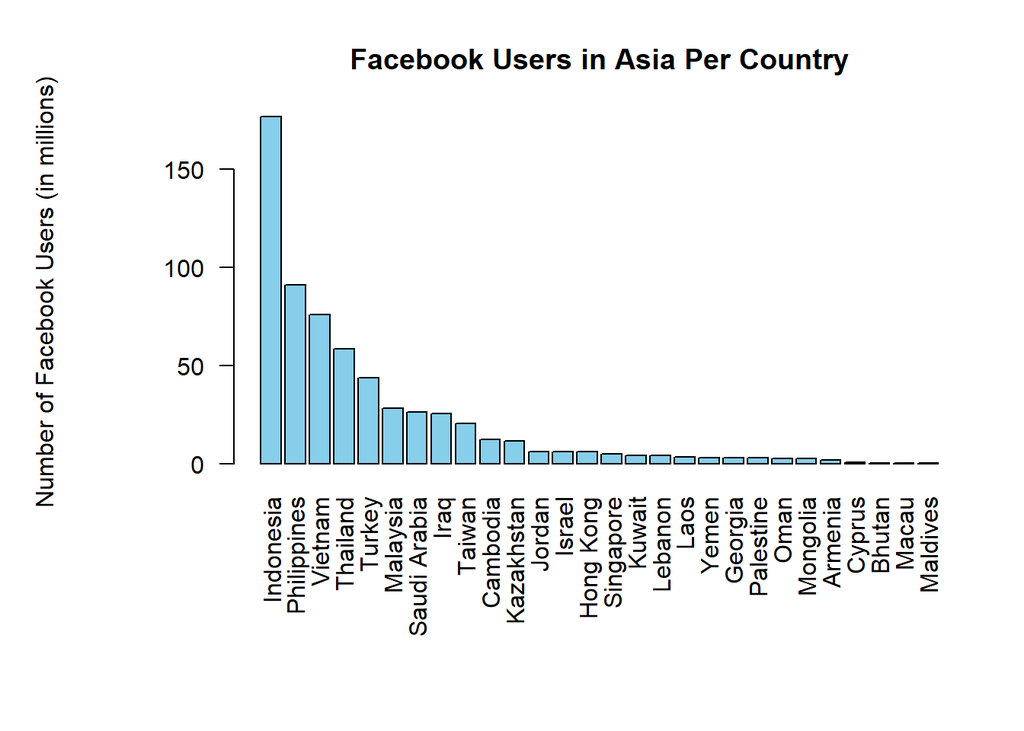

```r
par(mar = c(9, 8, 4, 2))
par(mgp = c(6, 1, 0))
Asia <- Facebook %>% filter(Continent == "Asia")

barplot(Asia$Users_mill,
        names.arg = Asia$Name,
        las = 2,
        col = "skyblue",
        main = "Facebook Users in Asia Per Country",
        ylab = "Number of Facebook Users (in millions)")
```

### Americas

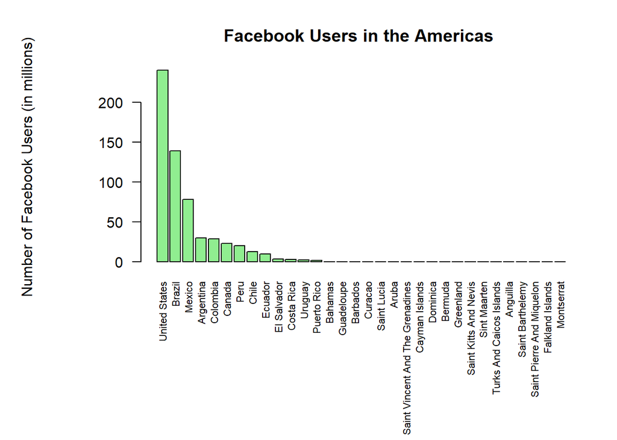

```r
par(mar = c(10, 8, 4, 2))
par(mgp = c(6, 1, 0))
Americas<- Facebook %>% filter(Continent == "Americas")

barplot(Americas$Users_mill,
        names.arg =Americas$Name,
        las = 2,
        col = "lightgreen",
        main = "Facebook Users in the Americas ",
        ylab = "Number of Facebook Users (in millions)",
        cex.names = 0.7)
```

### Europe

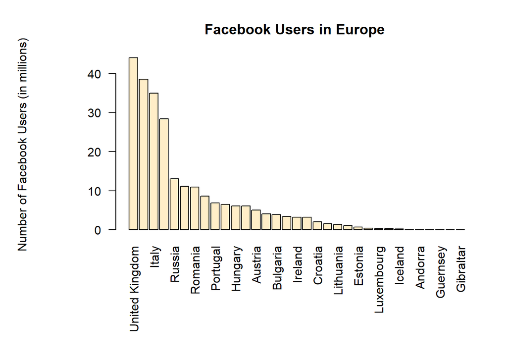

```r
par(mar = c(9, 8, 4, 2))
par(mgp = c(6, 1, 0))
Europe<- Facebook %>% filter(Continent == "Europe")

barplot(Europe$Users_mill,
        names.arg = Europe$Name,
        las = 2,
        col = "#FFEEC8",
        main = "Facebook Users in Europe ",
        ylab = "Number of Facebook Users (in millions)")
```

### Africa

[figure not shown]

```r
par(mar = c(9, 8, 4, 2))
par(mgp = c(6, 1, 0))
Africa<- Facebook %>% filter(Continent == "Africa")

barplot(Africa$Users_mill,
        names.arg = Africa$Name,
        las = 2,
        col = "#FFC067",
        main = "Facebook Users in Africa ",
        ylab = "Number of Facebook Users (in millions)")
```

### Ocenia

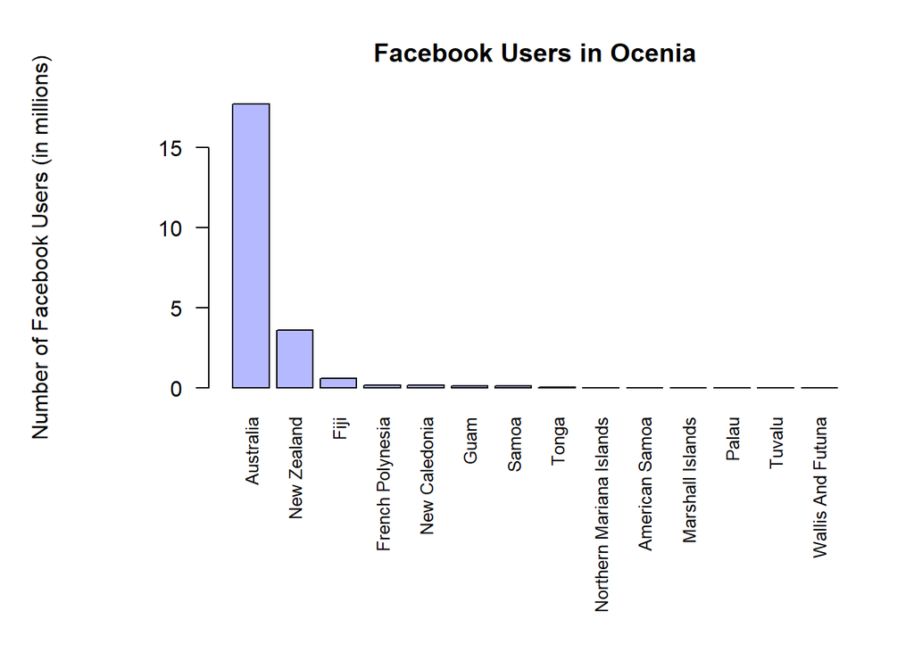

```r
par(mar = c(10, 8, 4, 2))
par(mgp = c(6, 1, 0))
Oceania<- Facebook %>% filter(Continent == "Oceania")

barplot(Oceania$Users_mill,
        names.arg = Oceania$Name,
        las = 2,
        col = "#b5b9ff",
        main = "Facebook Users in Ocenia",
        ylab = "Number of Facebook Users (in millions)",
        cex.names = 0.8)
```

# Results

*a. Analysis Method* — The data was first cleaned and formatted to make sure all values were numeric and usable. Countries were grouped by their respective continent and a scalled down column of users and population was added for easier vizualisaion during plotting. The methods used were: - Scatterplots, used to compare the total Facebook users and percentage of users with population(globally).

*c. Overall Findings* — By creating the scatterplots and barplots, we were able to visualize trends and patterns in the data. I observed that the Number of users increases with population, although some countries like Russia appeared as outliers. The user percentage showed less correlation with population, many countries just clustered around 50–80%, showing that population alone does not determine the % of Facebook users.

# Conclusions

This data provided global Facebook usage information acroos 126 countries. It was found that:

- The Population size of a country influences the total user amount, but not necessarily the user percentage.
- There are regional differences in Facebook adoption, which are visible in barplots and scatterplots.
- There are visible outliers in the graphs, suggesting that other factors can influence in user behavior.

*Limitations:* — limitations to this analysis, only 126 countries are included,having some of the most populated countries across all continents completely missing from this analysis.Factors such as internet access or other useful information to determine the reason for outliers in graphs are not included.

## References

- This data was downloaded fromm kaggle: “FB_bycountrydata”